# Project 3

Team DAREZ

10/17/2020

# Introduction

As recent as March of 2019 we are still hearing repeatedly that the demand of data scientists is not being met. The University of Pennsylvania states “Data analytics is becoming mission-critical to more and more businesses.” They quote LinkedIn co-found Allen Blue saying, “There are very few data scientists out here passing out their resumes. Data scientists are almost all already employed, because they’re so much in demand.” (https://knowledge.wharton.upenn.edu/article/whats-driving-demand-data-scientist/)

Data scientists come in many different flavors and from many different backgrounds as well, so often it comes down to having the right set of skills for the job. So what are those specific skills, other than it saying “data scientist” on your business card, that are in demand?

We set out to use our growing data science skills to begin looking at the data on what skills are in demand for data science. We chose to use 3 datasets, each looking at a slightly different angle of the question, “Which are the most valued data science skills?”

First, we looked at the 2019 Kaggle Survey on Data Science and Machine Learning. This massive, world-wide survey asks some pertinent questions of what specific tools and skills current practitioners are using. Next, we accessed a scrape of Glassdoor job postings that bring in the perspective of what hiring companies are asking for. Finally, a scrape of Indeed job postings was used to look at trends such as job locations and salaries. In a sense, these tell us what the job market expects of data scientists on a larger scale in terms of where we are willing to live and what salary is acceptable.

## Setup

Packages needed for this project include:

```r
#some packages repeated, but nice to know which sections they were used in

# For Web-scrap of Indeed
library(rvest)
library(readr)
library(tidyverse)
library(DT)
library(xml2)

# For graphing and nice tables
library(ggplot2)
library(rcartocolor)
library(kableExtra)

# SQL database connection
library(odbc)
library(DBI)

#packages for glassdoor
library(tidyverse)
library(openintro)
library (readr)
library(tidyr)
library(dplyr)
library(stringr)
library(wordcloud)
library(tidytext)
library(igraph)
library(ggraph)

#package for Kaggle Survey
library (tidyverse)
library (stringr)
```

### Database Connection: Azure

We wanted to store our data in an Azure online database. We created an account and initialized the database. We set up permissions and granted each user access to the database based on their IP addresses.

We created tables for each of the data sources and imported the data to each table, saving the import packages as SSIS (.dtsx) files. The initial tables included one table for the survey information from both Indeed and Glassdoor, and three tables to store the Kaggle survey data. We also created a “read only” user account that was shared with each of the team members so that they could read the data. The “read only” connection is in the code below:

```r
library(odbc) # create connection to SQL database
library(DBI)  # query SQL database tables

# connect to the server
my_connection <- dbConnect(drv = odbc::odbc(),
         Driver = "SQL Server",
         server = "data607.database.windows.net",
         database = "Project3",
         uid = "Professor607",
         pwd = "TeamDAREZ#1")
```

What follows is our step-by-step method of importing the data from the database into R. The flow began by reading the data from our Indeed web-scrape into its dataframe. This process is repeated until each source is extracted from the database and in their own dataframes. It was completed using the DBI package’s `dbGetQuery` function. Snippets of information containing the number of observations and the number of variables were written above the block of code that was used to read the data. Small examples of the imported data are also shown beneath the chunks.

#### Importing Indeed

Reading the Indeed web-scrape data into a dataframe. It contains 1524 observations of 7 variables.

```r
# read indeed data into a data frame named "df_indeed"
df_indeed <- dbGetQuery(my_connection,'
  SELECT "SurveyID", "source", "title", "company", "location", "summary", "link"
  FROM "indeed_scrape_1"
  WHERE "source" = \'indeed\'
')

head(df_indeed)
```

|  | SurveyID | source | title | company | location | summary | link |
| --- | --- | --- | --- | --- | --- | --- | --- |
| 1 | 1 | indeed | Data Scientist | Cognowiz solutions LLC | Herndon, VA | · Ideal candidate should have a degree in a quantitative field (e.g., mathematics, computer science, physics, economics, engineering, statistics, operations… | https://www.indeed.com/company/Cognowiz-solutions-LLC/jobs/Data-Scientist-dd25f8809ed80778?fccid=6f3afb2c19af6e1b&vjs=3 |
| 2 | 2 | indeed | Data Scientist, Intermediate | UVA Medical Center | Charlottesville, VA | Collaborate with assigned departments to provide actionable data-driven insights through research and analysis of data sources and development of statistical… | https://www.indeed.com/rc/clk?jk=7f539cf07d667e63&fccid=ac3ca395d43dcd7d&vjs=3 |
| 3 | 3 | indeed | Data Scientist | Bains Consulting LLC | Washington, DC | Our team is looking for Data Application/ Architect with one of the federal client Following are the skill sets the client is looking. - 10+ years of… | https://www.indeed.com/company/Bains-Consultiing-LLC/jobs/Data-Scientist-d45d4fe55396d210?fccid=a4daa6730e49fbd2&vjs=3 |
| 4 | 4 | indeed | Data Scientist | Arshi Systems Inc. | Charlotte, NC | Our client is one of the world’s leading petrochemical companies with a presence in 31 countries, 94 manufacturing facilities, 16,000 employees, and $10B in… | https://www.indeed.com/company/Arshisystems/jobs/Data-Scientist-7f87061bd1cf7978?fccid=4d47293ec5364fb5&vjs=3 |
| 5 | 5 | indeed | Data Scientist | MedThink | Cary, NC | Are you a strategic, analytical thinker who is driven to find innovative solutions? Do you love finding insights and knowledge within large and/or complex… | https://www.indeed.com/rc/clk?jk=150f90500e0c7d8a&fccid=0b20e67a8cb5eab7&vjs=3 |
| 6 | 6 | indeed | Data Scientist | Lore Ventures | Palo Alto, CA | We are looking for a Data Scientist to analyze large amounts of raw information to find patterns that will help improve our company. We will rely on you to… | https://www.indeed.com/company/Lore-Ventures/jobs/Data-Scientist-35d4088a490e2b7f?fccid=4c45ad5264ad03c6&vjs=3 |

#### Importing Glassdoor

Reading the Glassdoor text data into a dataframe. It contains 1710 observations of 7 variables.

```r
# read Glassdoor data into a data frame named "df_Glassdoor"
df_Glassdoor <- dbGetQuery(my_connection,'
  SELECT "SurveyID", "source", "title", "company", "location", "summary", "link"
  FROM "indeed_scrape_1"
  WHERE "source" = \'Glassdoor\'
')

head(df_Glassdoor)
```

|  | SurveyID | source | title | company | location | summary | link |
| --- | --- | --- | --- | --- | --- | --- | --- |
| 1 | 1525 | Glassdoor | Data Scientist | GovTech\r3.6 | Singapore | We are looking for Data Scientists who are interested in using data to draw insights that will result in policy changes or business process optimisation, benefiting the public. The applicant will be s… | NA |
| 2 | 1526 | Glassdoor | Data Scientist | Boston Consulting Group\r4.3 | Singapore | Location:\rSingapore\r\rGeography:\rAsia Pacific\r\rCapabilities:\rBig data & advanced analytics\r\rIndustries:\rTechnology industries\r\rAbout Us\r\r\rBoston Consulting Group partners with leaders in… | NA |
| 3 | 1527 | Glassdoor | Data Scientist - Customer Experience Group | Dell Technologies\r4.1 | Singapore | Data Scientist\r\rSingapore\r\rDell provides the technology that transforms the way we all work and live. But we are more than a technology company ‰ÛÓ we are a people company. We inspire, challenge a… | NA |
| 4 | 1528 | Glassdoor | Sr. Data Scientist Smart Home | Amazon\r4.1 | Singapore, SG | The Dash Replenishment Service (DRS) is an innovative new hardware/service providing customers un-paralleled convenience. As part of Alexa Smart Home, the Dash mission is to develop highly differentia… | NA |
| 5 | 1529 | Glassdoor | Data Scientist | QuantumBlack\r4.1 | Singapore | Analytics\rData Scientist - QuantumBlack\r\rSingapore City\r\rApply Now\r\rQualifications\r\rMSc or PhD level in the field of Computer Science, Machine Learning, Applied Statistics, Mathematics\rExper… | NA |
| 6 | 1530 | Glassdoor | Data Scientist | Citi\r3.6 | Singapore | Job Purpose:\r\rWe are looking for a Data Scientist to join our team to work on varied and challenging projects across the financial markets businesses. You will work closely with the sales and tradin… | NA |

#### Importing Kaggle Survey Schema

Reading the Kaggle industry survey schema into a dataframe. It contains 10 observations of 35 variables.

```r
# read survey schema data into a data frame named "df_survey_schema"
df_survey_schema <- dbGetQuery(my_connection,'
  SELECT "2019 Kaggle Machine Learning and Data Science Survey", "Q1", "Q2", "Q3", "Q4"
  , "Q5", "Q6", "Q7", "Q8", "Q9", "Q10", "Q11", "Q12", "Q13", "Q14", "Q15", "Q16", "Q17"
  , "Q18", "Q19", "Q20", "Q21", "Q22", "Q23", "Q24", "Q25", "Q26", "Q27", "Q28", "Q29"
  , "Q30", "Q31", "Q32", "Q33", "Q34"
  FROM "survey_schema"
')

head(df_survey_schema)
```

|  | 2019 Kaggle Machine Learning and Data Science Survey | Q1 | Q2 | Q3 | Q4 | Q5 | Q6 | Q7 | Q8 | Q9 | Q10 | Q11 | Q12 | Q13 | Q14 | Q15 | Q16 | Q17 | Q18 | Q19 | Q20 | Q21 | Q22 | Q23 | Q24 | Q25 | Q26 | Q27 | Q28 | … |
| --- | --- | --- | --- | --- | --- | --- | --- | --- | --- | --- | --- | --- | --- | --- | --- | --- | --- | --- | --- | --- | --- | --- | --- | --- | --- | --- | --- | --- | --- | --- |
| 1 | Question: | What is your age (# years)? | What is your gender? - Selected Choice | In which country do you currently reside? | What is the highest level of formal education that you have attained or plan to attain within the next 2 years? | Select the title most similar to your current role (or most recent title if retired): - Selected Choice | What is the size of the company where you are employed? | Approximately how many individuals are responsible for data science workloads at your place of business? | Does your current employer incorporate machine learning methods into their business? | Select any activities that make up an important part of your role at work: (Select all that apply) - Selected Choice | What is your current yearly compensation (approximate $USD)? | Approximately how much money have you spent on machine learning and/or cloud computing products at your work in the past 5 years? | Who/what are your favorite media sources that report on data science topics? (Select all that apply) - Selected Choice | On which platforms have you begun or completed data science courses? (Select all that apply) - Selected Choice | What is the primary tool that you use at work or school to analyze data? (Include text response) - Selected Choice | How long have you been writing code to analyze data (at work or at school)? | Which of the following integrated development environments (IDE's) do you use on a regular basis? (Select all that apply) - Selected Choice | Which of the following hosted notebook products do you use on a regular basis? (Select all that apply) - Selected Choice | What programming languages do you use on a regular basis? (Select all that apply) - Selected Choice | What programming language would you recommend an aspiring data scientist to learn first? - Selected Choice | What data visualization libraries or tools do you use on a regular basis? (Select all that apply) - Selected Choice | Which types of specialized hardware do you use on a regular basis? (Select all that apply) - Selected Choice | Have you ever used a TPU (tensor processing unit)? | For how many years have you used machine learning methods? | Which of the following ML algorithms do you use on a regular basis? (Select all that apply): - Selected Choice | Which categories of ML tools do you use on a regular basis? (Select all that apply) - Selected Choice | Which categories of computer vision methods do you use on a regular basis? (Select all that apply) - Selected Choice | Which of the following natural language processing (NLP) methods do you use on a regular basis? (Select all that apply) - Selected Choice | Which of the following machine learning frameworks do you use on a regular basis? (Select all that apply) - Selected Choice | … |
| 2 | # of Respondents: | 19717 | 19717 | 19717 | 19323 | 19107 | 14002 | 13623 | 13227 | 9226 | 12497 | 12250 | 16781 | 16569 | 15690 | 15627 | 14627 | 14443 | 14404 | 14377 | 14253 | 14218 | 14203 | 14182 | 14088 | 13915 | 5492 | 3582 | 13753 | … |
| 3 | Who was excluded? (0 = not excluded; 1 = excluded) | 0 | 0 | 0 | 0 | 0 | 0 | 0 | 0 | 0 | 0 | 0 | 0 | 0 | 0 | 0 | 0 | 0 | 0 | 0 | 0 | 0 | 0 | 0 | 0 | 0 | 0 | 0 | 0 | … |
| 4 | IfÂ What is your age (# years)?Â 0-17Â Is Selected | 0 | 1 | 1 | 1 | 1 | 1 | 1 | 1 | 1 | 1 | 1 | 1 | 1 | 1 | 1 | 1 | 1 | 1 | 1 | 1 | 1 | 1 | 1 | 1 | 1 | 1 | 1 | 1 | … |
| 5 | IfÂ Select the title most similar to your current role (or most recent title if retired):Â StudentÂ Is SelectedÂ OR Select the title most similar to your current role (or most recent title if retired)… | 0 | 0 | 0 | 0 | 0 | 1 | 1 | 1 | 1 | 1 | 1 | 0 | 0 | 0 | 0 | 0 | 0 | 0 | 0 | 0 | 0 | 0 | 0 | 0 | 0 | 0 | 0 | 0 | … |
| 6 | IfÂ How long have you been writing code to analyze data (at work or at school)?Â I have never written codeÂ Is SelectedÂ | 0 | 0 | 0 | 0 | 0 | 0 | 0 | 0 | 0 | 0 | 0 | 0 | 0 | 0 | 0 | 1 | 1 | 1 | 1 | 1 | 1 | 1 | 1 | 1 | 1 | 1 | 1 | 1 | … |

#### Importing Kaggle Survey’s MC Responses

Reading the Kaggle industry survey multiple choice responses into a dataframe. It contains 19,718 observations of 246 variables.

```r
# read survey multiple choice data into a data frame named "df_survey_multi_choice"

df_survey_multi_choice <- dbGetQuery(my_connection,'
  SELECT "Time from Start to Finish (seconds)"
  , "Q1", "Q2", "Q2_OTHER_TEXT", "Q3", "Q4", "Q5", "Q5_OTHER_TEXT"
  , "Q6", "Q7", "Q8", "Q9_Part_1", "Q9_Part_2", "Q9_Part_3", "Q9_Part_4"
  , "Q9_Part_5", "Q9_Part_6", "Q9_Part_7", "Q9_Part_8", "Q9_OTHER_TEXT"
  , "Q10", "Q11", "Q12_Part_1", "Q12_Part_2", "Q12_Part_3", "Q12_Part_4", "Q12_Part_5"
  , "Q12_Part_6", "Q12_Part_7", "Q12_Part_8", "Q12_Part_9", "Q12_Part_10", "Q12_Part_11"
  , "Q12_Part_12", "Q12_OTHER_TEXT", "Q13_Part_1", "Q13_Part_2", "Q13_Part_3", "Q13_Part_4"
  , "Q13_Part_5", "Q13_Part_6", "Q13_Part_7", "Q13_Part_8", "Q13_Part_9", "Q13_Part_10"
  , "Q13_Part_11", "Q13_Part_12", "Q13_OTHER_TEXT", "Q14", "Q14_Part_1_TEXT", "Q14_Part_2_TEXT"
  , "Q14_Part_3_TEXT", "Q14_Part_4_TEXT", "Q14_Part_5_TEXT", "Q14_OTHER_TEXT", "Q15"
  , "Q16_Part_1", "Q16_Part_2", "Q16_Part_3", "Q16_Part_4", "Q16_Part_5", "Q16_Part_6"
  , "Q16_Part_7", "Q16_Part_8", "Q16_Part_9", "Q16_Part_10", "Q16_Part_11", "Q16_Part_12", "Q16_OTHER_TEXT"
  , "Q17_Part_1", "Q17_Part_2", "Q17_Part_3", "Q17_Part_4", "Q17_Part_5", "Q17_Part_6", "Q17_Part_7", "Q17_Part_8"
  , "Q17_Part_9", "Q17_Part_10", "Q17_Part_11", "Q17_Part_12", "Q17_OTHER_TEXT", "Q18_Part_1", "Q18_Part_2"
  , "Q18_Part_3", "Q18_Part_4", "Q18_Part_5", "Q18_Part_6", "Q18_Part_7", "Q18_Part_8", "Q18_Part_9", "Q18_Part_10"
  , "Q18_Part_11", "Q18_Part_12", "Q18_OTHER_TEXT", "Q19", "Q19_OTHER_TEXT", "Q20_Part_1", "Q20_Part_2"
  , "Q20_Part_3", "Q20_Part_4", "Q20_Part_5", "Q20_Part_6", "Q20_Part_7"
  , "Q20_Part_8", "Q20_Part_9", "Q20_Part_10", "Q20_Part_11", "Q20_Part_12", "Q20_OTHER_TEXT", "Q21_Part_1"
  , "Q21_Part_2", "Q21_Part_3", "Q21_Part_4", "Q21_Part_5", "Q21_OTHER_TEXT", "Q22", "Q23", "Q24_Part_1"
  , "Q24_Part_2", "Q24_Part_3", "Q24_Part_4", "Q24_Part_5", "Q24_Part_6", "Q24_Part_7", "Q24_Part_8"
  , "Q24_Part_9", "Q24_Part_10", "Q24_Part_11", "Q24_Part_12", "Q24_OTHER_TEXT", "Q25_Part_1", "Q25_Part_2"
  , "Q25_Part_3", "Q25_Part_4", "Q25_Part_5", "Q25_Part_6", "Q25_Part_7", "Q25_Part_8", "Q25_OTHER_TEXT"
  , "Q26_Part_1", "Q26_Part_2", "Q26_Part_3", "Q26_Part_4", "Q26_Part_5", "Q26_Part_6", "Q26_Part_7"
  , "Q26_OTHER_TEXT", "Q27_Part_1", "Q27_Part_2", "Q27_Part_3", "Q27_Part_4", "Q27_Part_5", "Q27_Part_6"
  , "Q27_OTHER_TEXT", "Q28_Part_1", "Q28_Part_2", "Q28_Part_3", "Q28_Part_4", "Q28_Part_5", "Q28_Part_6"
  , "Q28_Part_7", "Q28_Part_8", "Q28_Part_9", "Q28_Part_10", "Q28_Part_11", "Q28_Part_12", "Q28_OTHER_TEXT"
  , "Q29_Part_1", "Q29_Part_2", "Q29_Part_3", "Q29_Part_4", "Q29_Part_5", "Q29_Part_6", "Q29_Part_7", "Q29_Part_8"
  , "Q29_Part_9", "Q29_Part_10", "Q29_Part_11", "Q29_Part_12", "Q29_OTHER_TEXT"
  , "Q30_Part_1", "Q30_Part_2", "Q30_Part_3", "Q30_Part_4", "Q30_Part_5", "Q30_Part_6", "Q30_Part_7"
  , "Q30_Part_8", "Q30_Part_9", "Q30_Part_10", "Q30_Part_11", "Q30_Part_12", "Q30_OTHER_TEXT"
  , "Q31_Part_1", "Q31_Part_2", "Q31_Part_3", "Q31_Part_4", "Q31_Part_5", "Q31_Part_6", "Q31_Part_7"
  , "Q31_Part_8", "Q31_Part_9", "Q31_Part_10", "Q31_Part_11", "Q31_Part_12", "Q31_OTHER_TEXT"
  , "Q32_Part_1", "Q32_Part_2", "Q32_Part_3", "Q32_Part_4", "Q32_Part_5", "Q32_Part_6", "Q32_Part_7"
  , "Q32_Part_8", "Q32_Part_9", "Q32_Part_10", "Q32_Part_11", "Q32_Part_12", "Q32_OTHER_TEXT"
  , "Q33_Part_1", "Q33_Part_2", "Q33_Part_3", "Q33_Part_4", "Q33_Part_5", "Q33_Part_6"
  , "Q33_Part_7", "Q33_Part_8", "Q33_Part_9", "Q33_Part_10", "Q33_Part_11", "Q33_Part_12", "Q33_OTHER_TEXT"
  , "Q34_Part_1", "Q34_Part_2", "Q34_Part_3", "Q34_Part_4", "Q34_Part_5", "Q34_Part_6"
  , "Q34_Part_7", "Q34_Part_8", "Q34_Part_9", "Q34_Part_10", "Q34_Part_11", "Q34_Part_12", "Q34_OTHER_TEXT"
  FROM "multiple_choice_responses"
')

head(df_survey_multi_choice)
```

|  | Time from Start to Finish (seconds) | Q1 | Q2 | Q2_OTHER_TEXT | Q3 | Q4 | Q5 | Q5_OTHER_TEXT | Q6 | Q7 | Q8 | Q9_Part_1 | Q9_Part_2 | Q9_Part_3 | Q9_Part_4 | Q9_Part_5 | Q9_Part_6 | Q9_Part_7 | Q9_Part_8 | Q9_OTHER_TEXT | Q10 | Q11 | Q12_Part_1 | Q12_Part_2 | Q12_Part_3 | Q12_Part_4 | Q12_Part_5 | Q12_Part_6 | Q12_Part_7 | … |
| --- | --- | --- | --- | --- | --- | --- | --- | --- | --- | --- | --- | --- | --- | --- | --- | --- | --- | --- | --- | --- | --- | --- | --- | --- | --- | --- | --- | --- | --- | --- |
| 1 | 36225 | 45-49 | Male | -1 | India | Master’s degree |  | -1 |  |  |  |  |  |  |  |  |  |  |  | -1 |  |  |  |  |  |  |  |  |  | … |
| 2 | 147 | 22-24 | Female | -1 | Indonesia | Master’s degree | Data Analyst | -1 | 0-49 employees | 1-2 | I do not know |  |  |  |  |  |  |  |  | -1 | $0-999 |  |  |  |  |  |  |  |  | … |
| 3 | 650 | 25-29 | Prefer not to say | -1 | France | Master’s degree |  | -1 |  |  |  |  |  |  |  |  |  |  |  | -1 |  |  |  |  |  |  |  |  |  | … |
| 4 | 157 | 30-34 | Male | -1 | Turkey | Bachelor’s degree | Software Engineer | -1 | 1000-9,999 employees | 10-14 | I do not know |  |  |  |  |  |  |  |  | -1 | 20,000-24,999 | $100-$999 | Twitter (data science influencers) | Hacker News (https://news.ycombinator.com/) |  |  |  |  |  | … |
| 5 | 10001 | 45-49 | Male | -1 | Other | Master’s degree | Other | 64 | 250-999 employees | 5-9 | I do not know |  |  |  |  |  |  |  |  | -1 | 1,000-1,999 | $100-$999 |  |  |  |  |  |  |  | … |
| 6 | 402 | 50-54 | Male | -1 | Brazil | Master’s degree | Data Scientist | -1 | 250-999 employees | 10-14 | We recently started using ML methods (i.e., models in production for less than 2 years) |  |  | Build prototypes to explore applying machine learning to new areas |  |  |  |  |  | -1 | 10,000-14,999 | $1000-$9,999 |  |  | Reddit (r/machinelearning, r/datascience, etc) |  | Course Forums (forums.fast.ai, etc) |  | Podcasts (Chai Time Data Science, Linear Digressions, etc) | … |

#### Importing Other Kaggle Responses

Reading the Kaggle industry survey responses listed as “other” into a dataframe. It contains 19,718 observations of 28 variables.

```r
# read survey other text response (free form) data into a data frame named "df_survey_other_text"

df_survey_other_text <- dbGetQuery(my_connection,'
  SELECT "Q12_OTHER_TEXT", "Q13_OTHER_TEXT", "Q14_OTHER_TEXT", "Q14_Part_1_TEXT", "Q14_Part_2_TEXT"
  , "Q14_Part_3_TEXT", "Q14_Part_4_TEXT", "Q14_Part_5_TEXT", "Q16_OTHER_TEXT", "Q17_OTHER_TEXT", "Q18_OTHER_TEXT"
  , "Q19_OTHER_TEXT", "Q20_OTHER_TEXT", "Q21_OTHER_TEXT"
  , "Q24_OTHER_TEXT", "Q25_OTHER_TEXT", "Q26_OTHER_TEXT", "Q27_OTHER_TEXT", "Q28_OTHER_TEXT", "Q29_OTHER_TEXT"
  , "Q2_OTHER_TEXT", "Q30_OTHER_TEXT", "Q31_OTHER_TEXT", "Q32_OTHER_TEXT", "Q33_OTHER_TEXT", "Q34_OTHER_TEXT"
  , "Q5_OTHER_TEXT", "Q9_OTHER_TEXT"
  FROM "other_text_responses"
')

head(df_survey_other_text)
```

|  | Q12_OTHER_TEXT | Q13_OTHER_TEXT | Q14_OTHER_TEXT | Q14_Part_1_TEXT | Q14_Part_2_TEXT | Q14_Part_3_TEXT | Q14_Part_4_TEXT | Q14_Part_5_TEXT | Q16_OTHER_TEXT | Q17_OTHER_TEXT | Q18_OTHER_TEXT | Q19_OTHER_TEXT | Q20_OTHER_TEXT | Q21_OTHER_TEXT | Q24_OTHER_TEXT | Q25_OTHER_TEXT | Q26_OTHER_TEXT | Q27_OTHER_TEXT | Q28_OTHER_TEXT | Q29_OTHER_TEXT | Q2_OTHER_TEXT | Q30_OTHER_TEXT | Q31_OTHER_TEXT | Q32_OTHER_TEXT | Q33_OTHER_TEXT | Q34_OTHER_TEXT | Q5_OTHER_TEXT | Q9_OTHER_TEXT |
| --- | --- | --- | --- | --- | --- | --- | --- | --- | --- | --- | --- | --- | --- | --- | --- | --- | --- | --- | --- | --- | --- | --- | --- | --- | --- | --- | --- | --- |
| 1 | Who/what are your favorite media sources that report on data science topics? (Select all that apply) - Other - Text | On which platforms have you begun or completed data science courses? (Select all that apply) - Other - Text | What is the primary tool that you use at work or school to analyze data? (Include text response) - Other - Text | What is the primary tool that you use at work or school to analyze data? (Include text response) - Basic statistical software (Microsoft Excel, Google Sheets, etc.) - Text | What is the primary tool that you use at work or school to analyze data? (Include text response) - Advanced statistical software (SPSS, SAS, etc.) - Text | What is the primary tool that you use at work or school to analyze data? (Include text response) - Business intelligence software (Salesforce, Tableau, Spotfire, etc.) - Text | What is the primary tool that you use at work or school to analyze data? (Include text response) - Local development environments (RStudio, JupyterLab, etc.) - Text | What is the primary tool that you use at work or school to analyze data? (Include text response) - Cloud-based data software & APIs (AWS, GCP, Azure, etc.) - Text | Which of the following integrated development environments (IDE's) do you use on a regular basis? (Select all that apply) - Other - Text | Which of the following hosted notebook products do you use on a regular basis? (Select all that apply) - Other - Text | What programming languages do you use on a regular basis? (Select all that apply) - Other - Text | What programming language would you recommend an aspiring data scientist to learn first? - Other - Text | What data visualization libraries or tools do you use on a regular basis? (Select all that apply) - Other - Text | Which types of specialized hardware do you use on a regular basis? (Select all that apply) - Other - Text | Which of the following ML algorithms do you use on a regular basis? (Select all that apply): - Other - Text | Which categories of ML tools do you use on a regular basis? (Select all that apply) - Other - Text | Which categories of computer vision methods do you use on a regular basis? (Select all that apply) - Other - Text | Which of the following natural language processing (NLP) methods do you use on a regular basis? (Select all that apply) - Other - Text | Which of the following machine learning frameworks do you use on a regular basis? (Select all that apply) - Other - Text | Which of the following cloud computing platforms do you use on a regular basis? (Select all that apply) - Other - Text | What is your gender? - Prefer to self-describe - Text | Which specific cloud computing products do you use on a regular basis? (Select all that apply) - Other - Text | Which specific big data / analytics products do you use on a regular basis? (Select all that apply) - Other - Text | Which of the following machine learning products do you use on a regular basis? (Select all that apply) - Other - Text | Which automated machine learning tools (or partial AutoML tools) do you use on a regular basis? (Select all that apply) - Other - Text | Which of the following relational database products do you use on a regular basis? (Select all that apply) - Other - Text | Select the title most similar to your current role (or most recent title if retired): - Other - Text | Select any activities that make up an important part of your role at work: (Select all that apply) - Other - Text |
| 2 | "> |  |  | Sheets |  |  |  |  |  |  |  |  |  |  |  |  |  |  |  |  |  |  |  |  |  |  |  | "> |
| 3 |  |  |  | Microsoft Excel |  |  |  |  |  |  |  |  |  |  |  |  |  |  |  |  |  |  |  |  |  |  |  |  |
| 4 |  |  |  | D |  |  |  |  |  |  |  |  |  |  |  |  |  |  |  |  |  |  |  |  |  |  |  |  |
| 5 |  |  |  | Microsoft Excel |  |  |  |  |  |  |  |  |  |  |  |  |  |  |  |  |  |  |  |  |  |  |  |  |
| 6 | Newsletters |  |  |  |  |  | Python scripts |  |  |  |  |  |  |  |  |  |  |  |  |  |  |  |  |  |  |  |  |  |

# Analysis

First, we look at the 2019 Kaggle Survey on Data Science and Machine Learning. This massive, world-wide survey asks some pertinent questions of what specific tools and skills current practitioners are using.

Next, we access a scrape of Glassdoor job postings that bring in the perspective of what hiring companies are asking for.

Finally, a scrape of Indeed job postings is used to look at trends such as job locations and salaries as in a sense, these tell us what the job market expects of data scientists on a larger scale in terms of where we are willing to live and what salary is acceptable

## Kaggle 2019 Survey Data

For three weeks from October 8 to October 28 of 2019 Kaggle conducted an industry-wide survey with 19,717 responses from individuals in the data science and machine learning fields. Responses were aggregated into a file with data from 171 countries and any country that had less than 50 responses was placed in an “other” category to preserve anonymity of the respondents. The data collected gives a comprehensive look at the state of the industry by asking questions about their education, workplace habits, tools in use and more. It was formatted as a multiple-choice survey wherein responses could be categorized into one of several options for each question.

We selected this data set to give us the most comprehensive look at the skills and general expectations of the data science and machine learning job market. We decided to select questions that were most relevant to our interests. Here are a few examples:

```
* What programming languages do you use on a regular basis?
* What programming language would you recommend an aspiring data scientist to learn first?
* Which of the following relational database products do you use on a regular basis?
```

These were used in the analysis but prior to performing any computations, the data required cleaning. Due to the way the survey was shuffled to preserve anonymity, the responses needed to be organized into a format that was usable to analyze. With the multiple-choice responses uploaded to our database and GitHub repository as a spreadsheet (.csv) we began to organize and clean the data.

### Tidying and Munging the Kaggle Data

The 2019 Kaggle survey contains thirty-four questions and the corresponding recorded responses. We decided to make a dataframe for each question and response. The code to accomplish this task is below for each dataframe. It is formatted for ease of viewing to see how each question was cleaned and summarized.

```
Q1 - What is your age (# years)?
```

```r
# create dataframe just for question 1

q_01 <- dbGetQuery(my_connection,'
  SELECT "Q1"
    FROM "multiple_choice_responses"
    wHERE "Q1" != \'\'
      AND "Q1" NOT LIKE \'%?%\'  -- remove the record with the question
')

q_01 <- data.frame(q_01) %>%
  gather(key="question", value="response")  %>%
    group_by(response) %>%
      summarize(count_reponse = n())

q_01
```

| response | count_reponse |
| --- | --- |
| 18-21 | 2502 |
| 22-24 | 3610 |
| 25-29 | 4458 |
| 30-34 | 3120 |
| 35-39 | 2087 |
| 40-44 | 1439 |
| 45-49 | 949 |
| 50-54 | 692 |
| 55-59 | 422 |
| 60-69 | 338 |

[output cut: 1 more lines]

```
Q2 - What is your gender?
```

```r
# create dataframe just for question 2

q_02 <- dbGetQuery(my_connection,'
  SELECT "Q2"
    FROM "multiple_choice_responses"
    wHERE "Q2" != \'\'
      AND "Q2" NOT LIKE \'%?%\'  -- remove the record with the question
')

q_02 <- data.frame(q_02) %>%
  gather(key="question", value="response")  %>%
    group_by(response) %>%
      summarize(count_reponse = n())

q_02
```

| response | count_reponse |
| --- | --- |
| Female | 3212 |
| Male | 16138 |
| Prefer not to say | 318 |
| Prefer to self-describe | 49 |

```
Q3 - In which country do you currently reside?
```

```r
# create dataframe just for question 3

q_03 <- dbGetQuery(my_connection,'
  SELECT "Q3"
    FROM "multiple_choice_responses"
    wHERE "Q3" != \'\'
      AND "Q3" NOT LIKE \'%?%\'  -- remove the record with the question
')

q_03 <- data.frame(q_03) %>%
  gather(key="question", value="response")  %>%
    group_by(response) %>%
      summarize(count_reponse = n())

q_03
```

| response | count_reponse |
| --- | --- |
| Algeria | 58 |
| Argentina | 123 |
| Australia | 269 |
| Austria | 53 |
| Bangladesh | 136 |
| Belarus | 68 |
| Belgium | 70 |
| Brazil | 728 |
| Canada | 450 |
| Chile | 91 |

[output cut: 49 more lines]

```
Q4 - What is the highest level of formal education that you have attained or
plan to attain within the next 2 years?
```

```r
# create dataframe just for question 4

q_04 <- dbGetQuery(my_connection,'
  SELECT "Q4"
    FROM "multiple_choice_responses"
    wHERE "Q4" != \'\'
      AND "Q4" NOT LIKE \'%?%\'  -- remove the record with the question
')

q_04 <- data.frame(q_04) %>%
  gather(key="question", value="response")  %>%
    group_by(response) %>%
      summarize(count_reponse = n())

q_04
```

| response | count_reponse |
| --- | --- |
| Bachelor’s degree | 5993 |
| Doctoral degree | 2767 |
| I prefer not to answer | 333 |
| Master’s degree | 8549 |
| No formal education past high school | 233 |
| Professional degree | 611 |
| Some college/university study without earning a bachelor’s degree | 837 |

```
Q5 - Select the title most similar to your current role (or most recent title if retired):
```

```r
# create dataframe just for question 5

q_05 <- dbGetQuery(my_connection,'
  SELECT "Q5"
    FROM "multiple_choice_responses"
    wHERE "Q5" != \'\'
      AND "Q5" NOT LIKE \'%?%\'  -- remove the record with the question
')

q_05 <- data.frame(q_05) %>%
  gather(key="question", value="response")  %>%
    group_by(response) %>%
      summarize(count_reponse = n())

q_05
```

| response | count_reponse |
| --- | --- |
| Business Analyst | 778 |
| Data Analyst | 1598 |
| Data Engineer | 624 |
| Data Scientist | 4085 |
| DBA/Database Engineer | 156 |
| Not employed | 942 |
| Other | 1690 |
| Product/Project Manager | 723 |
| Research Scientist | 1470 |
| Select the title most similar to your current role (or most recent title if retired): - Selected Choice | 1 |

[output cut: 3 more lines]

```
Q6 - What is the size of the company where you are employed?
```

```r
# create dataframe just for question 6

q_06 <- dbGetQuery(my_connection,'
  SELECT "Q6"
    FROM "multiple_choice_responses"
    wHERE "Q6" != \'\'
      AND "Q6" NOT LIKE \'%?%\'  -- remove the record with the question
')

q_06 <- data.frame(q_06) %>%
  gather(key="question", value="response")  %>%
    group_by(response) %>%
      summarize(count_reponse = n())

q_06
```

| response | count_reponse |
| --- | --- |
| > 10,000 employees | 3160 |
| 0-49 employees | 4025 |
| 1000-9,999 employees | 2641 |
| 250-999 employees | 1847 |
| 50-249 employees | 2329 |

```
Q7 - Approximately how many individuals are responsible for data science
workloads at your place of business?
```

```r
# create dataframe just for question 7

q_07 <- dbGetQuery(my_connection,'
  SELECT "Q7"
    FROM "multiple_choice_responses"
    wHERE "Q7" != \'\'
      AND "Q7" NOT LIKE \'%?%\'  -- remove the record with the question
')

q_07 <- data.frame(q_07) %>%
  gather(key="question", value="response")  %>%
    group_by(response) %>%
      summarize(count_reponse = n())

q_07
```

| response | count_reponse |
| --- | --- |
| 0 | 1880 |
| 1-2 | 3005 |
| 10-14 | 967 |
| 15-19 | 427 |
| 20+ | 3178 |
| 3-4 | 2319 |
| 5-9 | 1847 |

```
Q8 - Does your current employer incorporate machine learning methods into their business?
```

```r
# create dataframe just for question 8

q_08 <- dbGetQuery(my_connection,'
  SELECT "Q8"
    FROM "multiple_choice_responses"
    wHERE "Q8" != \'\'
      AND "Q8" NOT LIKE \'%?%\'  -- remove the record with the question
')

q_08 <- data.frame(q_08) %>%
  gather(key="question", value="response")  %>%
    group_by(response) %>%
      summarize(count_reponse = n())

q_08
```

| response | count_reponse |
| --- | --- |
| I do not know | 1191 |
| No (we do not use ML methods) | 2415 |
| We are exploring ML methods (and may one day put a model into production) | 2812 |
| We have well established ML methods (i.e., models in production for more than 2 years) | 2528 |
| We recently started using ML methods (i.e., models in production for less than 2 years) | 2731 |
| We use ML methods for generating insights (but do not put working models into production) | 1550 |

```
Q9 - Select any activities that make up an important part of your role at work:
(Select all that apply) - Selected Choice
```

```r
# create dataframe just for question 9

q_09 <- dbGetQuery(my_connection,'
  SELECT "Q9_Part_1", "Q9_Part_2", "Q9_Part_3", "Q9_Part_4"
        , "Q9_Part_5", "Q9_Part_6", "Q9_Part_7", "Q9_Part_8"
    FROM "multiple_choice_responses"
    wHERE "Q9_Part_1" NOT LIKE \'%selected Choice%\'  -- remove the record with the questions
')

q_09 <- data.frame(q_09) %>%
  gather(key="question", value="response")  %>%
    group_by(response) %>%
      summarize(count_reponse = n())

q_09
```

| response | count_reponse |
| --- | --- |
|  | 132906 |
| Analyze and understand data to influence product or business decisions | 6091 |
| Build and/or run a machine learning service that operationally improves my product or workflows | 3348 |
| Build and/or run the data infrastructure that my business uses for storing, analyzing, and operationalizing data | 3566 |
| Build prototypes to explore applying machine learning to new areas | 4981 |
| Do research that advances the state of the art of machine learning | 2359 |
| Experimentation and iteration to improve existing ML models | 3705 |
| None of these activities are an important part of my role at work | 531 |
| Other | 249 |

```
Q10 - What is your current yearly compensation (approximate $USD)?
```

```r
# create dataframe just for question 10

q_10 <- dbGetQuery(my_connection,'
  SELECT "Q10"
    FROM "multiple_choice_responses"
    wHERE "Q10" != \'\'
      AND "Q10" NOT LIKE \'%?%\'  -- remove the record with the question
')

q_10 <- data.frame(q_10) %>%
  gather(key="question", value="response")  %>%
    group_by(response) %>%
      summarize(count_reponse = n())

q_10
```

| response | count_reponse |
| --- | --- |
| $0-999 | 1513 |
| > $500,000 | 83 |
| 1,000-1,999 | 599 |
| 10,000-14,999 | 833 |
| 100,000-124,999 | 750 |
| 125,000-149,999 | 483 |
| 15,000-19,999 | 529 |
| 150,000-199,999 | 434 |
| 2,000-2,999 | 390 |
| 20,000-24,999 | 526 |

[output cut: 15 more lines]

```
Q11 - Approximately how much money have you spent on machine learning and/or
cloud computing products at your work in the past 5 years?
```

```r
# create dataframe just for question 11

q_11 <- dbGetQuery(my_connection,'
  SELECT "Q11"
    FROM "multiple_choice_responses"
    wHERE "Q11" != \'\'
      AND "Q11" NOT LIKE \'%?%\'  -- remove the record with the question
')

q_11 <- data.frame(q_11) %>%
  gather(key="question", value="response")  %>%
    group_by(response) %>%
      summarize(count_reponse = n())

q_11
```

| response | count_reponse |
| --- | --- |
| $0 (USD) | 4038 |
| $1-$99 | 1485 |
| $10,000-$99,999 | 1268 |
| $100-$999 | 2335 |
| $1000-$9,999 | 2123 |
| > $100,000 ($USD) | 1001 |

```
Q12 - Who/what are your favorite media sources that report on data science
topics? (Select all that apply) - Selected Choice
```

```r
# create dataframe just for question 12

q_12 <- dbGetQuery(my_connection,'
  SELECT "Q12_Part_1", "Q12_Part_2", "Q12_Part_3", "Q12_Part_4"
        , "Q12_Part_5", "Q12_Part_6", "Q12_Part_7", "Q12_Part_8"
        , "Q12_Part_9", "Q12_Part_10", "Q12_Part_11"
        , "Q12_Part_12"
    FROM "multiple_choice_responses"
    wHERE "Q12_Part_1" NOT LIKE \'%selected Choice%\'  -- remove the record with the questions
')

q_12 <- data.frame(q_12) %>%
  gather(key="question", value="response")  %>%
    group_by(response) %>%
      summarize(count_reponse = n())

q_12 <- q_12[-1,]
q_12
```

| response | count_reponse |
| --- | --- |
| Blogs (Towards Data Science, Medium, Analytics Vidhya, KDnuggets etc) | 9907 |
| Course Forums (forums.fast.ai, etc) | 3755 |
| Hacker News (https://news.ycombinator.com/) | 1804 |
| Journal Publications (traditional publications, preprint journals, etc) | 4472 |
| Kaggle (forums, blog, social media, etc) | 10751 |
| None | 575 |
| Other | 1184 |
| Podcasts (Chai Time Data Science, Linear Digressions, etc) | 2075 |
| Reddit (r/machinelearning, r/datascience, etc) | 3419 |
| Slack Communities (ods.ai, kagglenoobs, etc) | 2412 |

[output cut: 2 more lines]

```
Q13 - On which platforms have you begun or completed data science courses?
(Select all that apply) - Selected Choice
```

```r
# create dataframe just for question 13

q_13 <- dbGetQuery(my_connection,'
  SELECT "Q13_Part_1", "Q13_Part_2", "Q13_Part_3", "Q13_Part_4", "Q13_Part_5"
        , "Q13_Part_6", "Q13_Part_7", "Q13_Part_8", "Q13_Part_9", "Q13_Part_10"
        , "Q13_Part_11", "Q13_Part_12"
    FROM "multiple_choice_responses"
    wHERE "Q13_Part_1" NOT LIKE \'%selected Choice%\'  -- remove the record with the questions
')

q_13 <- data.frame(q_13) %>%
  gather(key="question", value="response")  %>%
    group_by(response) %>%
      summarize(count_reponse = n())

q_13 <- q_13[-1,]
q_13
```

| response | count_reponse |
| --- | --- |
| Coursera | 8685 |
| DataCamp | 3843 |
| DataQuest | 743 |
| edX | 3150 |
| Fast.ai | 1520 |
| Kaggle Courses (i.e. Kaggle Learn) | 5119 |
| LinkedIn Learning | 1283 |
| None | 1491 |
| Other | 1872 |
| Udacity | 2953 |

[output cut: 2 more lines]

```
Q14 - What is the primary tool that you use at work or school to analyze data?
(Include text response) - Selected Choice
```

```r
# create dataframe just for question 14

q_14 <- dbGetQuery(my_connection,'
  SELECT "Q14"
    FROM "multiple_choice_responses"
    wHERE "Q14" != \'\'
      AND "Q14" NOT LIKE \'%?%\'  -- remove the record with the question
')

q_14 <- data.frame(q_14) %>%
  gather(key="question", value="response")  %>%
    group_by(response) %>%
      summarize(count_reponse = n())

q_14
```

| response | count_reponse |
| --- | --- |
| Advanced statistical software (SPSS, SAS, etc.) | 895 |
| Basic statistical software (Microsoft Excel, Google Sheets, etc.) | 3061 |
| Business intelligence software (Salesforce, Tableau, Spotfire, etc.) | 881 |
| Cloud-based data software & APIs (AWS, GCP, Azure, etc.) | 1188 |
| Local development environments (RStudio, JupyterLab, etc.) | 8475 |
| Other | 1190 |

```
Q15 - How long have you been writing code to analyze data (at work or at school)?
```

```r
# create dataframe just for question 15

q_15 <- dbGetQuery(my_connection,'
  SELECT "Q15"
    FROM "multiple_choice_responses"
    wHERE "Q15" != \'\'
      AND "Q15" NOT LIKE \'%?%\'  -- remove the record with the question
')

q_15 <- data.frame(q_15) %>%
  gather(key="question", value="response")  %>%
    group_by(response) %>%
      summarize(count_reponse = n())

q_15
```

| response | count_reponse |
| --- | --- |
| < 1 years | 3828 |
| 1-2 years | 4061 |
| 10-20 years | 1045 |
| 20+ years | 576 |
| 3-5 years | 3365 |
| 5-10 years | 1887 |
| I have never written code | 865 |

```
Q16 - Which of the following integrated development environments (IDE's) do
you use on a regular basis? (Select all that apply) - Selected Choice
```

```r
# create dataframe just for question 16

q_16 <- dbGetQuery(my_connection,'
  SELECT "Q16_Part_1", "Q16_Part_2", "Q16_Part_3", "Q16_Part_4", "Q16_Part_5"
      , "Q16_Part_6", "Q16_Part_7", "Q16_Part_8", "Q16_Part_9", "Q16_Part_10"
      , "Q16_Part_11", "Q16_Part_12"
    FROM "multiple_choice_responses"
    wHERE "Q16_Part_1" NOT LIKE \'%selected Choice%\'  -- remove the record with the questions
')

q_16 <- data.frame(q_16) %>%
  gather(key="question", value="response")  %>%
    group_by(response) %>%
      summarize(count_reponse = n())

q_16 <- q_16[-1,]
q_16
```

| response | count_reponse |
| --- | --- |
| Notepad++ | 3281 |
| Spyder | 3085 |
| Sublime Text | 2655 |
| Vim / Emacs | 1782 |
| Atom | 1487 |
| MATLAB | 1768 |
| PyCharm | 4224 |
| RStudio | 4455 |
| Visual Studio / Visual Studio Code | 4534 |
| Jupyter (JupyterLab, Jupyter Notebooks, etc) | 10804 |

[output cut: 2 more lines]

```
Q17 - Which of the following hosted notebook products do you use on a regular
basis? (Select all that apply) - Selected Choice
```

```r
# create dataframe just for question 17

q_17 <- dbGetQuery(my_connection,'
  SELECT "Q17_Part_1", "Q17_Part_2", "Q17_Part_3", "Q17_Part_4", "Q17_Part_5"
        , "Q17_Part_6", "Q17_Part_7", "Q17_Part_8", "Q17_Part_9", "Q17_Part_10"
        , "Q17_Part_11", "Q17_Part_12"
    FROM "multiple_choice_responses"
    wHERE "Q17_Part_1" NOT LIKE \'%selected Choice%\'  -- remove the record with the questions
')

q_17 <- data.frame(q_17) %>%
  gather(key="question", value="response")  %>%
    group_by(response) %>%
      summarize(count_reponse = n())

q_17 <- q_17[-1,]
q_17
```

| response | count_reponse |
| --- | --- |
| Binder / JupyterHub | 1681 |
| FloydHub | 101 |
| Google Cloud Notebook Products (AI Platform, Datalab, etc) | 1121 |
| Google Colab | 4551 |
| IBM Watson Studio | 669 |
| Kaggle Notebooks (Kernels) | 4845 |
| Microsoft Azure Notebooks | 855 |
| Paperspace / Gradient | 142 |
| AWS Notebook Products (EMR Notebooks, Sagemaker Notebooks, etc) | 757 |
| Code Ocean | 76 |

[output cut: 2 more lines]

In this review of the Kaggle survey, we were able to summarize the selected multiple-choice responses. This allows us to see what respondents in the industry expect from new data scientists and it provided evidence of what to expect in the future.

### Kaggle Analysis

Aspiring data scientist and current data science professionals may be interested in knowing what the industry expectations are as they are constantly changing. As new software and analysis methods appear, we make changes to our processes and create new programs, develop new models, and improve our data systems. To understand these trends, we took a well-rounded approach.

The data we selected provides a snapshot in time of those industry skills, tools, and expectations. We have three sources to gather information from; a large, global survey called the Kaggle Survey, a web-scrape of current jobs offered on Indeed, and a textual analysis of another web-scrape compiled from Glassdoor. We begin with the Kaggle survey.

#### Dataset:Multiple Choice Responses

```r
Data <- dbGetQuery(my_connection,"Select * FROM dbo.multiple_choice_responses")
```

Converting to a tibble

```r
Data_Tibble <-as_tibble(Data)
```

Filtering out non data roles Since our research question is “What are the most sought after skills for data scientists?” we are only interested in looking at the information for data roles.

```r
DataScientists <- filter (Data_Tibble,Q5 == "Data Scientist" | Q5 == "Data Analyst" | Q5 == "Data Engineer")
```

#### Responses

We are going to store the responses for **questions 18-34** in separate data frames (q_18,q_19,q_20 and so on till q_34).However, we have excluded questions that are not relevant for our analysis (non skills based questions)

Question 18:What programming languages do you use on a regular basis?

```r
q_18 <- DataScientists %>%
  select(starts_with("Q18")& !"Q18_OTHER_TEXT")
q_18 <-q_18 %>%
  gather(Q,Response)  %>%
    group_by(Response) %>%
      summarize(count_response = n())
```

Question 19: What programming language would you recommend an aspiring data scientist to learn first?

```r
q_19 <- DataScientists %>%
  select(starts_with("Q19")& !"Q19_OTHER_TEXT")
q_19 <- q_19 %>%
  gather(Q,Response)  %>%
    group_by(Response) %>%
      summarize(count_response = n())
```

Question 20: What data visualization libraries or tools do you use on a regular basis?

```r
q_20 <- DataScientists %>%
  select(starts_with("Q20")& !"Q20_OTHER_TEXT")

q_20 <-q_20 %>%
  gather(Q20,response)  %>%
    group_by(response) %>%
      summarize(count_response = n())
```

Question 24: Which of the following ML algorithms do you use on a regular basis?

```r
q_24 <- DataScientists %>%
  select(starts_with("Q24")& !"Q24_OTHER_TEXT")

q_24 <-q_24 %>%
  gather(Q,response)  %>%
    group_by(response) %>%
      summarize(count_response = n())
```

Question 25: Which categories of ML tools do you use on a regular basis?

```r
q_25 <- DataScientists %>%
  select(starts_with("Q25")& !"Q25_OTHER_TEXT")
q_25 <-q_25 %>%
  gather(Q,response)  %>%
    group_by(response) %>%
      summarize(count_response = n())
```

Question 26: Which categories of computer vision methods do you use on a regular basis?

```r
q_26 <- DataScientists %>%
  select(starts_with("Q26")& !"Q26_OTHER_TEXT")
q_26 %>%
  gather(Q26,response)  %>%
    group_by(response) %>%
      summarize(count_response = n())
```

| response | count_response |
| --- | --- |
|  | 40242 |
| General purpose image/video tools (PIL, cv2, skimage, etc) | 716 |
| Generative Networks (GAN, VAE, etc) | 346 |
| Image classification and other general purpose networks (VGG, Inception, ResNet, ResNeXt, NASNet, EfficientNet, etc) | 1078 |
| Image segmentation methods (U-Net, Mask R-CNN, etc) | 684 |
| None | 422 |
| Object detection methods (YOLOv3, RetinaNet, etc) | 640 |
| Other | 21 |

Question 27: Which of the following natural language processing (NLP) methods do you use on a regular basis?

```r
q_27 <- DataScientists %>%
  select(starts_with("Q27")& !"Q27_OTHER_TEXT")
q_27 %>%
  gather(Q27,response)  %>%
    group_by(response) %>%
      summarize(count_response = n())
```

| response | count_response |
| --- | --- |
|  | 35186 |
| Contextualized embeddings (ELMo, CoVe) | 281 |
| Encoder-decorder models (seq2seq, vanilla transformers) | 579 |
| None | 321 |
| Other | 28 |
| Transformer language models (GPT-2, BERT, XLnet, etc) | 499 |
| Word embeddings/vectors (GLoVe, fastText, word2vec) | 948 |

Question 28: Which of the following machine learning frameworks do you use on a regular basis?

```r
q_28 <- DataScientists %>%
  select(starts_with("Q28")& !"Q28_OTHER_TEXT")
q_28 <-q_28 %>%
  gather(Q,response)  %>%
    group_by(response) %>%
      summarize(count_response = n())
```

Question 29: Which of the following cloud computing platforms do you use on a regular basis?

```r
q_29 <- DataScientists %>%
  select(starts_with("Q29")& !"Q29_OTHER_TEXT")

q_29 <-q_29 %>%
  gather(Q29,response)  %>%
    group_by(response) %>%
      summarize(count_response = n())
```

Question 30: Which specific cloud computing products do you use on a regular basis?

```r
q_30 <- DataScientists %>%
  select(starts_with("Q30")& !"Q30_OTHER_TEXT")
q_30 <- q_30 %>%
  gather(Q30,response)  %>%
    group_by(response) %>%
      summarize(count_response = n())
```

Question 31: Which specific big data / analytics products do you use on a regular basis?

```r
q_31 <- DataScientists %>%
  select(starts_with("Q31")& !"Q31_OTHER_TEXT")

q_31 <-
q_31 %>%
  gather(Q31,response)  %>%
    group_by(response) %>%
      summarize(count_response = n())
```

Question 32: Which of the following machine learning products do you use on a regular basis?

```r
q_32 <- DataScientists %>%
  select(starts_with("Q32")& !"Q32_OTHER_TEXT")
q_32<- q_32 %>%
  gather(Q,response)  %>%
    group_by(response) %>%
      summarize(count_response = n())
```

Question 33: Which automated machine learning tools (or partial AutoML tools) do you use on a regular basis?

```r
q_33 <- DataScientists %>%
  select(starts_with("Q33")& !"Q33_OTHER_TEXT")
q_33 <-q_33 %>%
  gather(Q33,response)  %>%
    group_by(response) %>%
      summarize(count_reponse = n())
```

Question 34: Which of the following relational database products do you use on a regular basis?

```r
q_34 <- DataScientists %>%
  select(starts_with("Q34")& !"Q34_OTHER_TEXT")
q_34 <-q_34 %>%
  gather(Q,response)  %>%
    group_by(response) %>%
      summarize(count_response = n())
```

In this review of the Kaggle survey, we were able to summarize the selected multiple-choice responses. This allows us to see what respondents in the industry expect from aspiring and existing data scientists. It also provided evidence of what to expect in the future.

#### Most cited skills

It looks like the majority of the skills-based questions can be categorized into the following areas- 1.**Programming Languages**: Questions 18 and 19 2.**Data Visualization**: Question 20 3.**ML Tools and Products**: Questions 25,32 and 33 4.**ML Framework**: Question 28 5.**Big Data**: Question 31 6.**Cloud Platforms**: Questions 29 and 30 7.**Relational Databases**:Question 34 8.Computer Vision: Question 26 9.NLP: Question 27

We are particularly interested in understanding what the most cited tools or skills were for #1-6 above.

*1.Programming Languages*

We will combine the individual data frame for each question first before plotting the data.

```r
PL <- rbind(q_18,q_19)
PL <-PL %>%
    group_by(Response) %>%
      summarize(sum_response= sum(count_response))
knitr::kable(PL)
```

| Response | sum_response |
| --- | --- |
|  | 64030 |
| Bash | 866 |
| C | 312 |
| C++ | 453 |
| Java | 512 |
| Javascript | 534 |
| MATLAB | 361 |
| None | 30 |
| Other | 390 |
| Python | 8357 |
| R | 2579 |
| SQL | 3496 |
| TypeScript | 71 |

We don’t need to see the blank responses

```r
PL$Response[PL$Response == ""|PL$Response =="None"] <- NA
PL <-PL %>%
    group_by(Response) %>%
      summarize(sum_response= sum(sum_response))
PL <- na.omit(PL)
knitr::kable(PL)
```

| Response | sum_response |
| --- | --- |
| Bash | 866 |
| C | 312 |
| C++ | 453 |
| Java | 512 |
| Javascript | 534 |
| MATLAB | 361 |
| Other | 390 |
| Python | 8357 |
| R | 2579 |
| SQL | 3496 |
| TypeScript | 71 |

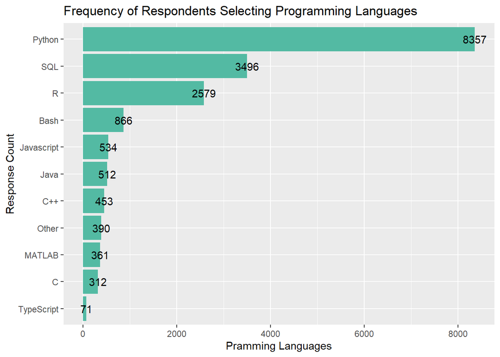

```r
PL$Response <- factor(PL$Response, levels = PL$Response[order(PL$sum_response)])

ggplot(data=PL, aes(x=Response,y=sum_response, fill=Response))+
  geom_col(fill="#53baa3") +
  geom_text(label=(PL$sum_response)) +
  ggtitle("Frequency of Respondents Selecting Programming Languages") +
  coord_flip() +
  xlab('Response Count') +
  ylab('Pramming Languages')
```

*2. Data Visualization*

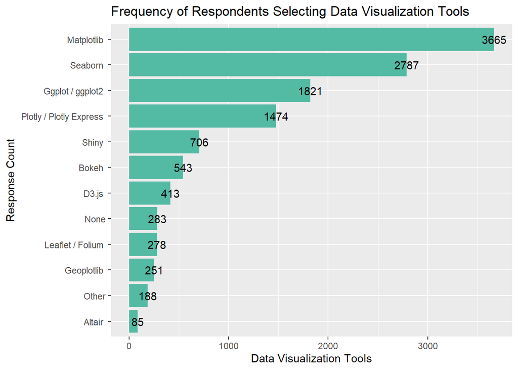

```r
q_20$response <- factor(q_20$response, levels = q_20$response[order(q_20$count_response)])

q_20graph <- q_20[-c(1), ]

ggplot(data=q_20graph, aes(x=response,y=count_response, fill=response))+
  geom_col(fill="#53baa3")+
  geom_text(label=(q_20graph$count_response))+
  ggtitle("Frequency of Respondents Selecting Data Visualization Tools") +
  coord_flip() +
  xlab('Response Count') +
  ylab('Data Visualization Tools')
```

*3. ML Algorithm*

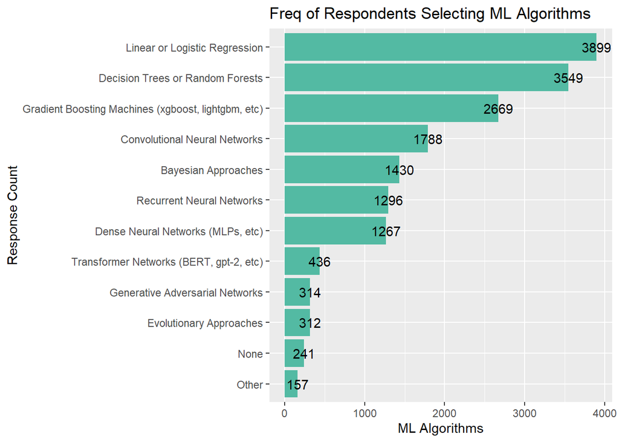

```r
q_24$response <- factor(q_24$response, levels = q_24$response[order(q_24$count_response)])

q_24graph <- q_24[-c(1), ]


ggplot(data=q_24graph, aes(x=response,y=count_response, fill=response)) +
  geom_col(fill="#53baa3") +
  geom_text(label=(q_24graph$count_response)) +
  ggtitle("Freq of Respondents Selecting ML Algorithms") +
  coord_flip() +
  xlab('Response Count') +
  ylab('ML Algorithms')
```

*4. ML Framework*

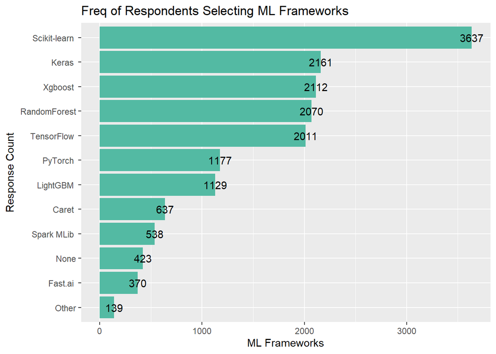

```r
q_28$response <- factor(q_28$response, levels = q_28$response[order(q_28$count_response)])

q_28graph <- q_28[-c(1), ]

ggplot(data=q_28graph, aes(x=response,y=count_response, fill=response)) +
  geom_col(fill="#53baa3") +
  geom_text(label=(q_28graph$count_response)) +
  ggtitle("Freq of Respondents Selecting ML Frameworks") +
  xlab('Response Count') +
  ylab('ML Frameworks') +
  coord_flip()
```

*5. Cloud Platforms*

```r
CloudPlatform <- rbind(q_29,q_30)
CloudPlatform <-CloudPlatform %>%
    group_by(response) %>%
      summarize(sum_response= sum(count_response))
knitr::kable(CloudPlatform)
```

| response | sum_response |
| --- | --- |
|  | 141085 |
| Alibaba Cloud | 47 |
| Amazon Web Services (AWS) | 1502 |
| Google Cloud Platform (GCP) | 1080 |
| IBM Cloud | 192 |
| Microsoft Azure | 711 |
| Oracle Cloud | 76 |
| Red Hat Cloud | 36 |
| Salesforce Cloud | 55 |
| SAP Cloud | 36 |
| VMware Cloud | 64 |
| AWS Batch | 149 |
| AWS Elastic Beanstalk | 144 |
| AWS Elastic Compute Cloud (EC2) | 1005 |
| AWS Lambda | 459 |
| Azure Container Service | 210 |
| Azure Virtual Machines | 442 |
| Google App Engine | 262 |
| Google Cloud Functions | 329 |
| Google Compute Engine (GCE) | 593 |
| Google Kubernetes Engine | 256 |
| None | 2425 |
| Other | 210 |